# HW #3

Orla O’Brien

2022-09-27

# Question 4.28: Darwin Data

## Are cross fertilized plants superior to self-fertilized plants?

First load in and name the data.

```
##   Cross  Self
## 1 23.50 17.38
## 2 12.00 20.38
## 3 21.00 20.00
## 4 22.00 20.00
## 5 19.13 18.38
## 6 21.50 18.63
```

### Draw a histogram of the differences

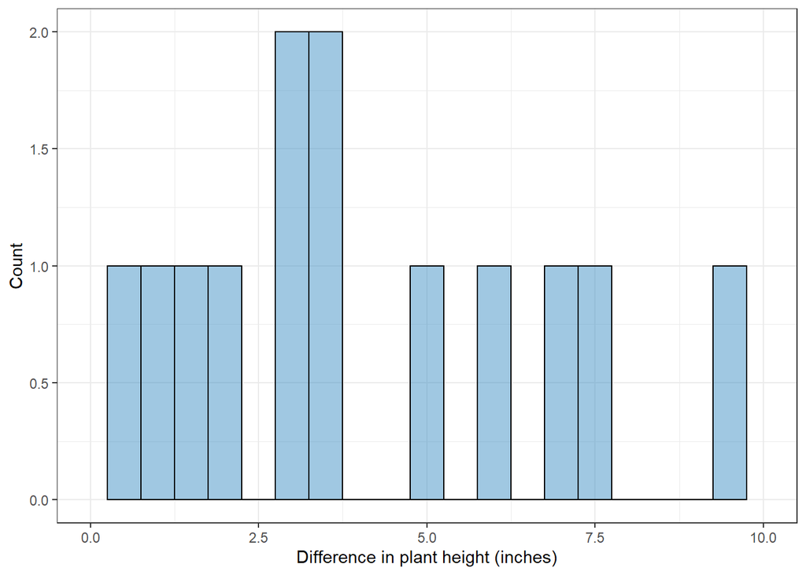

### Find a two-sided p-value for the hypothesis using a paired t-test

```
## [1] 0.04975881
```

### Find a 95% confidence interval for the additive treatment effect

```
## [1] 0.003165044 5.230168289
## attr(,"conf.level")
## [1] 0.95
```

### Is there any indication from the plot that the paired t-test is inappropriate?

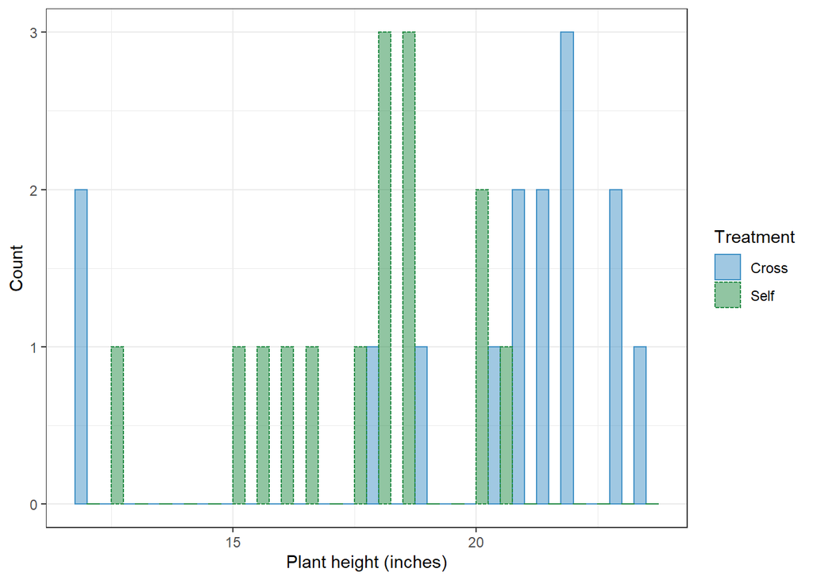

Based on both a histogram of heights and a histogram of difference in heights, I would say that the differences are not normally distributed, and thus a t-test is not appropriate.

### Find a two-sided p-value for the hypothesis using the signed-rank test.

```
## [1] 0.04125977
```

```
## [1] 0.50 5.19
## attr(,"conf.level")
## [1] 0.95
```

```
## (pseudo)median
##          3.125
```

### Conclusions

A paired t-test seemed to be appropriate because the data was comparing growth of plants under two different treatment (pollination) regimes. The data are continuous and the observations are independent of each other. However, the data do not meet the assumption that the differences between groups be normally distributed. Therefore, a signed-rank test was used. This test does not assume any distribution, and is more appropriate. The results of this test showed suggestive evidence of cross pollination resulting in plants growing higher (p-value = 0.04, 95% confidence interval 0.50 - 5.19).

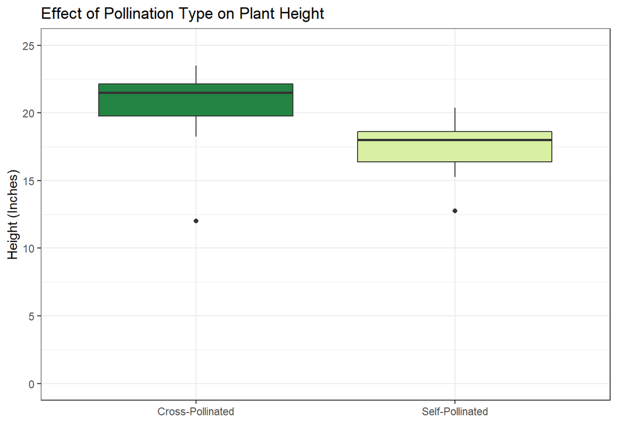

# Question 4.32: Therapeutic Marijuana

## Does marijuana treatment reduce the frequency of vomiting episodes?

Load in our data set.

```
##   Subject Marijuana Placebo
## 1       1        15      23
## 2       2        25      50
## 3       3         0       0
## 4       4         0      99
## 5       5         4      31
## 6       6         2      21
```

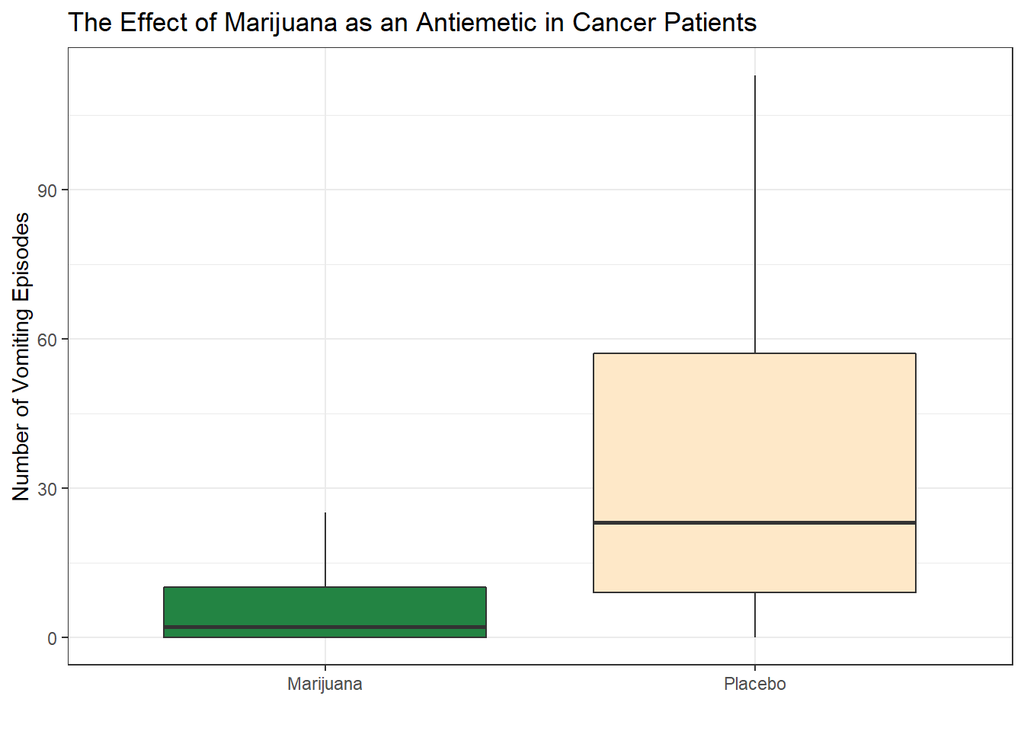

This boxplot shows that the data need to be log-transformed.

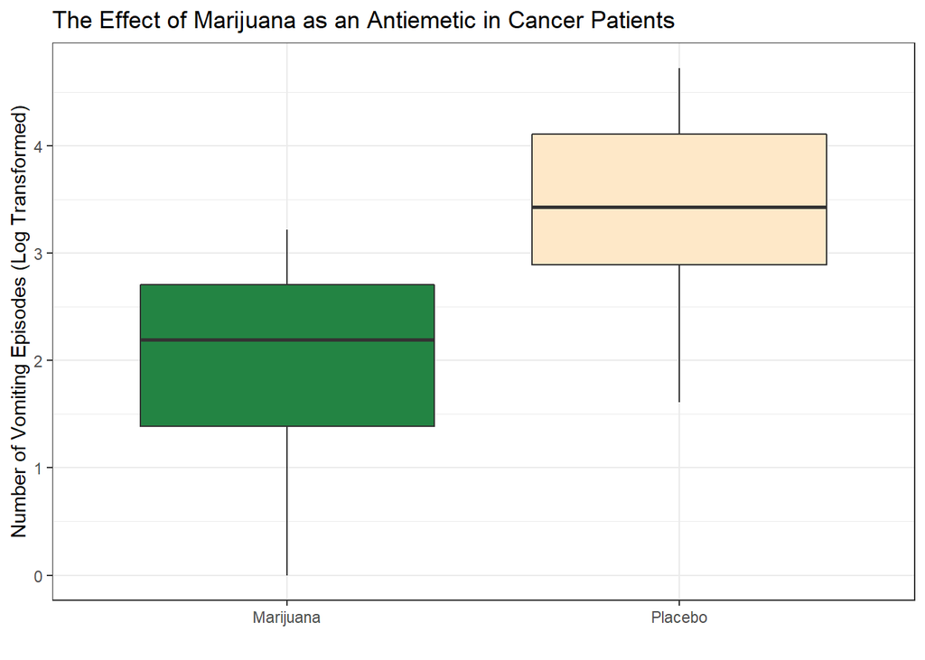

This looks much better, so I will proceed with the analysis using a log transformation.

```
## # A tibble: 6 x 5
## # Groups:   Subject [6]
##   Subject Marijuana Placebo  diff logDiff
##     <int>     <int>   <int> <int>   <dbl>
## 1       1        15      23     8    2.20
## 2       2        25      50    25    3.26
## 3       3         0       0     0    0
## 4       4         0      99    99    4.61
## 5       5         4      31    27    3.33
## 6       6         2      21    19    3.00
```

Note that some of the differences are zero, so I need to add one to take the log. Once log transformed, they still end up being zero. This means I need to use a version of the Wilcoxon signed rank test that allows for zeros (ties). The package asht uses a Pratt modification to deal with this.

```
##
##  Exact Wilcoxon Signed-Rank Test (with Pratt modification if zeros)
##
## data:  single sample=(dat32$logDiff)
## p-value = 0.0002441
## alternative hypothesis: true median is not equal to 0
## 95 percent confidence interval:
##  1.936 3.585
## sample estimates:
## median (Hodges-Lehmann estimator)
##                          2.864355
```

Now we need to back transform the confidence intervals and effect size.

```
## median (Hodges-Lehmann estimator)
##                          17.53774
```

[output not shown]

[output not shown]

# Question 4.30 Sleuth 2: Sunlight protection factor

## What is the SPF value of the sunscreen used in the study?

```
##   Control Sunscreen
## 1      30       120
## 2      45       240
## 3     180       480
## 4      15       150
## 5     200       480
## 6      20       270
```

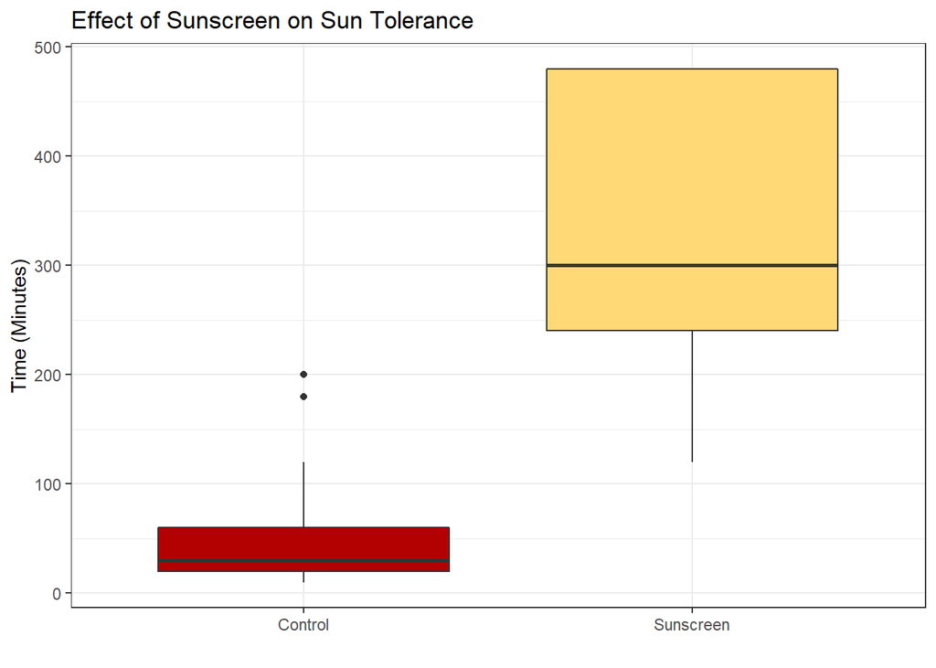

Looking at the data, we know we need to do a log transformation.

Here are the data shown again, once transformed.

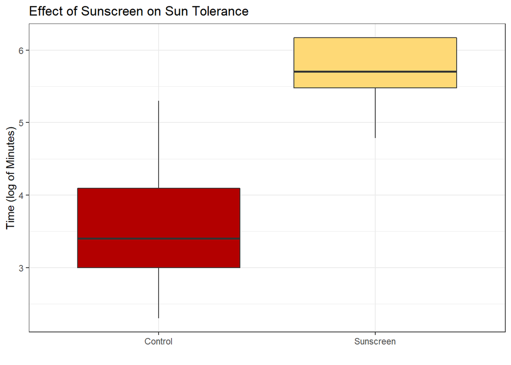

```
##
##  Exact Wilcoxon Signed-Rank Test (with Pratt modification if zeros)
##
## data:  log(dat30$Sunscreen) minus log(dat30$Control)
## p-value = 0.0002441
## alternative hypothesis: true median is not equal to 0
## 95 percent confidence interval:
##  1.5301 2.5053
## sample estimates:
## median (Hodges-Lehmann estimator)
##                          1.994515
```

We can use a Wilcoxon Signed-Rank test here. This gives us an exact p-value of .0002.

Then we need to back transform our estimate and confidence intervals.

```
## [1] 7.315534
```

```
## [1] 4.618177
```

```
## [1] 12.30493
```

## Question 4.31 Sleuth 2: Effect of group therapy on survival of breast cancer patients

### Does group therapy increase survival time for cancer patients

```
##   Survival   Group Censor
## 1        2 Control      0
## 2        6 Control      0
## 3        8 Control      0
## 4       10 Control      0
## 5       12 Control      0
## 6       12 Control      0
```

Lets view a boxplot of the data

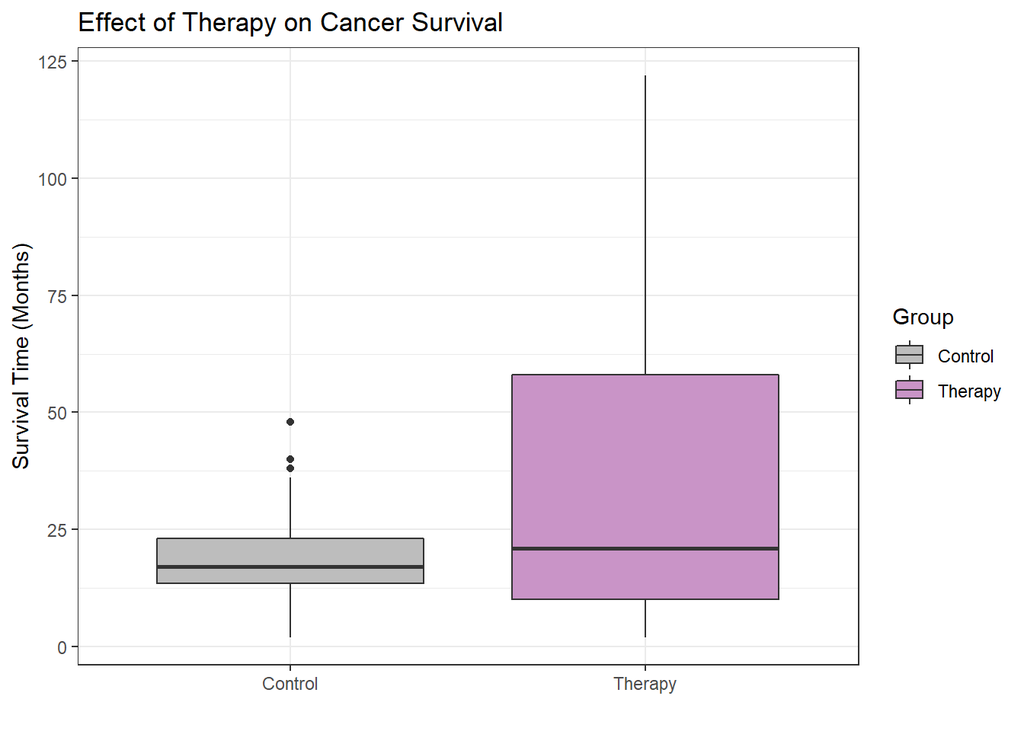

Need to do a log transform to deal with the variance in survival time

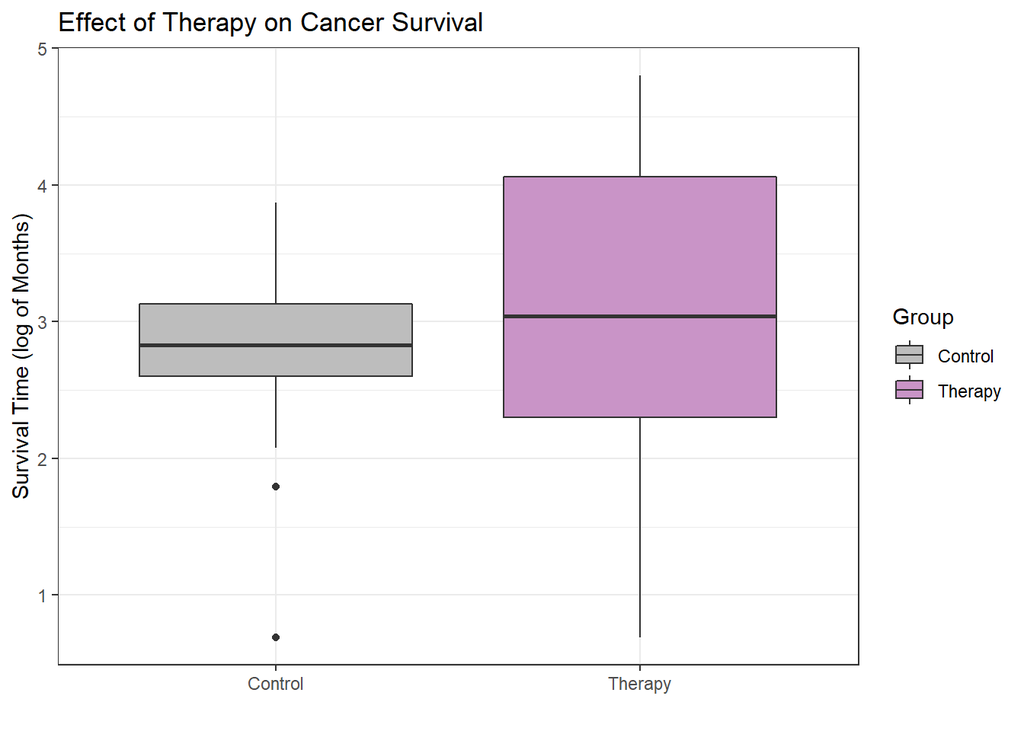

Because the data is censored, I used a rank sum test (as in the cognitive load test). After performing the test, I had to back transform the intervals and the estimate.

```
##
##  Wilcoxon rank sum test with continuity correction
##
## data:  log(Survival) by Group
## W = 337, p-value = 0.265
## alternative hypothesis: true location shift is not equal to 0
## 95 percent confidence interval:
##  -0.9807764  0.2513536
## sample estimates:
## difference in location
##             -0.3184537
```

```
## [1] 0.7276028
```

```
## [1] 0.374936
```

```
## [1] 1.28531
```

```
##     Survival          Group        Censor
##  Min.   :  2.00   Control:24   Min.   :0.00000
##  1st Qu.: 12.00   Therapy:34   1st Qu.:0.00000
##  Median : 18.00                Median :0.00000
##  Mean   : 31.41                Mean   :0.05172
##  3rd Qu.: 44.50                3rd Qu.:0.00000
##  Max.   :122.00                Max.   :1.00000
```

### Conclusions

Surprisingly, it seemed like therapy did not extend the life of the patient (p value 0.3). While there were patients in therapy groups that lived longer, I believe that there is a much larger spread in the data of that group that accounts for this. The effect size was 0.7 with a 95% confidence interval of 0.38 - 1.3. The interval crossing over 1 means that there is no convincing evidence therapy either extends or does not extend the life of the patient.